# Praca Domowa 1

Aleksander Podsiad

09.03.2020

# 1 Wstęp do analizy

Zbiór danych dotyczy wyników badań pod kątem chorób serca pacjentów z Cleveland.

## 1.1 Opis zmiennych

- age - integer - age of patient
- sex - integer - 1=male; 0=female
- cp - integer - chest pain type: 1=typical angina; 2=atypical angine; 3=non-anginal pain; 4=asymptomatic
- trestbps - integer - resting blood pressure (mm Hg)
- chol - integer - serum cholestrol (mg/dl)
- fbs - integer - fasting blood sugar: 1 if > 120 mg/dl; 0 otherwise
- restecg - integer - resting electrocardiographic results: 0=normal; 1=having ST-T wave abnormality; 2=showing probable or definite left ventricular hypertrophy
- thalach - integer - maximum heart rate achieved
- exang - integer - exercise induced angina: 1=yes; 0=no
- oldpeak - float - ST depression induced by exercise relative to rest
- slope - integer - the slope of the peak exercise ST segment: 1=upsloping; 2=flat; 3=downsloping
- ca - integer - number of major vessels (0-3) colored by flourosopy
- thal - integer - 3=normal; 6=fixed defect; 7=reversable defect
- num - integer - predicted attribute; 0=HEART DISEASE; 1=NO HEART DISEASE

## 1.2 Summary

Ładowanie pakietów i wstępna eksploracja danych:

```r
library(DataExplorer)
library(dplyr)
library(ggplot2)
data <- read.csv("heart_disease_dataset.csv")
summary(data)
```

```
##       age             sex               cp           trestbps
##  Min.   :29.00   Min.   :0.0000   Min.   :1.000   Min.   : 94.0
##  1st Qu.:48.00   1st Qu.:0.0000   1st Qu.:3.000   1st Qu.:120.0
##  Median :56.00   Median :1.0000   Median :3.000   Median :130.0
##  Mean   :54.44   Mean   :0.6799   Mean   :3.158   Mean   :131.7
##  3rd Qu.:61.00   3rd Qu.:1.0000   3rd Qu.:4.000   3rd Qu.:140.0
##  Max.   :77.00   Max.   :1.0000   Max.   :4.000   Max.   :200.0
##       chol            fbs            restecg          thalach
##  Min.   :126.0   Min.   :0.0000   Min.   :0.0000   Min.   : 71.0
##  1st Qu.:211.0   1st Qu.:0.0000   1st Qu.:0.0000   1st Qu.:133.5
##  Median :241.0   Median :0.0000   Median :1.0000   Median :153.0
##  Mean   :246.7   Mean   :0.1485   Mean   :0.9901   Mean   :149.6
##  3rd Qu.:275.0   3rd Qu.:0.0000   3rd Qu.:2.0000   3rd Qu.:166.0
##  Max.   :564.0   Max.   :1.0000   Max.   :2.0000   Max.   :202.0
##      exang           oldpeak         slope             ca
##  Min.   :0.0000   Min.   :0.00   Min.   :1.000   Min.   :-100000
##  1st Qu.:0.0000   1st Qu.:0.00   1st Qu.:1.000   1st Qu.:      0
##  Median :0.0000   Median :0.80   Median :2.000   Median :      0
##  Mean   :0.3267   Mean   :1.04   Mean   :1.601   Mean   :  -1319
##  3rd Qu.:1.0000   3rd Qu.:1.60   3rd Qu.:2.000   3rd Qu.:      1
##  Max.   :1.0000   Max.   :6.20   Max.   :3.000   Max.   :      3
##       thal                num
##  Min.   :-100000.0   Min.   :0.0000
##  1st Qu.:      3.0   1st Qu.:0.0000
##  Median :      3.0   Median :0.0000
##  Mean   :   -655.4   Mean   :0.4587
##  3rd Qu.:      7.0   3rd Qu.:1.0000
##  Max.   :      7.0   Max.   :1.0000
```

Summary wykazuje niepokojące wartości dla thal i ca. Są to zmienne dyskretne, więc zostaną zastąpione przez modę (nie jest dużo rekordów z brakami danych). Następnie wyczyszczę tabelę i poprawię zmienne dyskretne, dla których określanie rozkładów i średnich nie ma sensu.

```r
data[data$ca < 0, "ca"] <- 0
data[data$thal < 0, "thal"] <- 3

data1 <- data

data <- data %>%
  mutate(sex = case_when(
    sex == 1 ~ "male",
    sex == 0 ~ "female")) %>%
  mutate(cp = case_when(
    cp == 1 ~ "typical angina",
    cp == 2 ~ "atypical angine",
    cp == 3 ~ "non-anginal pain",
    cp == 4 ~ "asymptomatic")) %>%
  mutate(restecg = case_when(
    restecg == 0 ~ "normal",
    restecg == 1 ~ "ST-T wave abnormality",
    restecg == 2 ~ "ventricular hypertrophy")) %>%
  mutate(exang = case_when(
    exang == 1 ~ "yes",
    exang == 0 ~ "no")) %>%
  mutate(slope = case_when(
    slope == 1 ~ "upsloping",
    slope == 2 ~ "flat",
    slope == 3 ~ "downsloping")) %>%
  mutate(thal = case_when(
    thal == 3 ~ "normal",
    thal == 6 ~ "fixed defect",
    thal == 7 ~ "reversable defect")) %>%
  mutate(num = case_when(
    num == 0 ~ "HEART DISEASE",
    num == 1 ~ "NO HEART DISEASE")) %>%
  mutate(fbs = case_when(
    fbs == 1 ~ "> 120 mg/dl",
    fbs == 0 ~ "<= 120 mg/dl")) %>%
  mutate(ca = case_when(
    ca == 0 ~ "0",
    ca == 1 ~ "1",
    ca == 2 ~ "2",
    ca == 3 ~ "3"))
```

# 2 Rozkłady zmiennych

## 2.1 Wiek

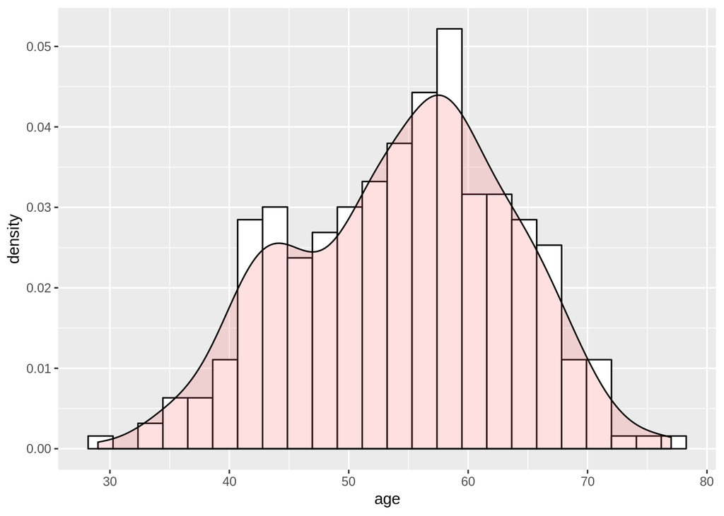

```r
ggplot(data, aes(x=age)) +
    geom_histogram(aes(y=..density..),
                   bins=24,
                   colour="black", fill="white") +
    geom_density(alpha=.2, fill="#FF6666")
```

## 2.2 Stężenie cholesterolu

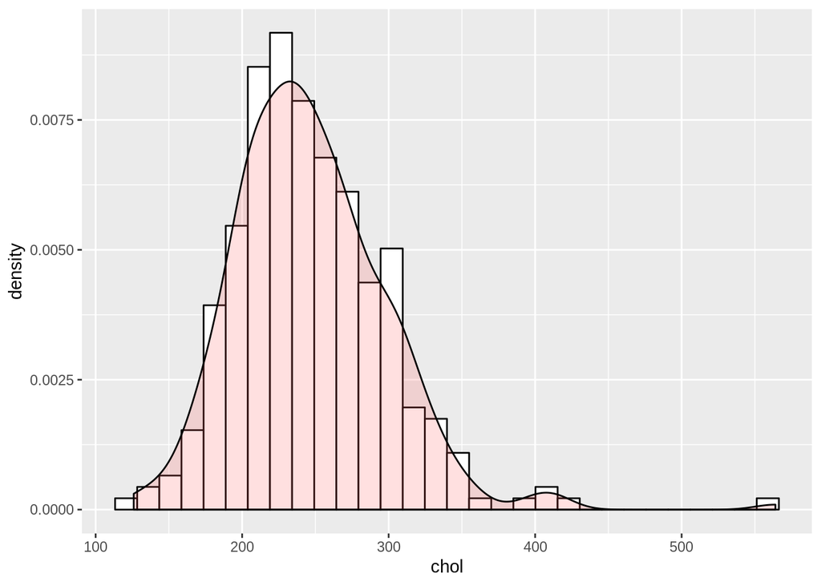

```r
ggplot(data, aes(x=chol)) +
    geom_histogram(aes(y=..density..),
                   bins=30,
                   colour="black", fill="white") +
    geom_density(alpha=.2, fill="#FF6666")
```

## 2.3 Obniżenie odcinka ST

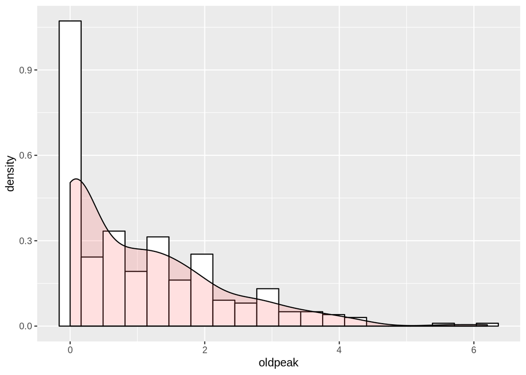

```r
ggplot(data, aes(x=oldpeak)) +
    geom_histogram(aes(y=..density..),
                   bins=20,
                   colour="black", fill="white") +
    geom_density(alpha=.2, fill="#FF6666")
```

## 2.4 Maksymalne osiągnięte tętno

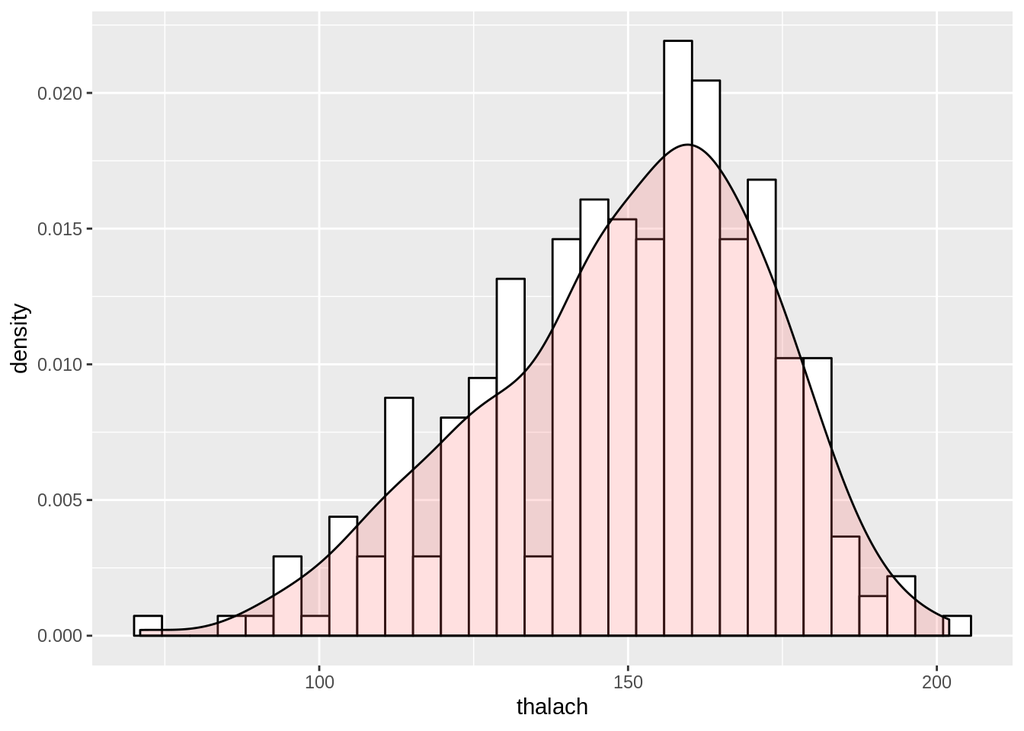

```r
ggplot(data, aes(x=thalach)) +
    geom_histogram(aes(y=..density..),
                   bins=30,
                   colour="black", fill="white") +
    geom_density(alpha=.2, fill="#FF6666")
```

## 2.5 Spoczynkowe ciśnienie krwii

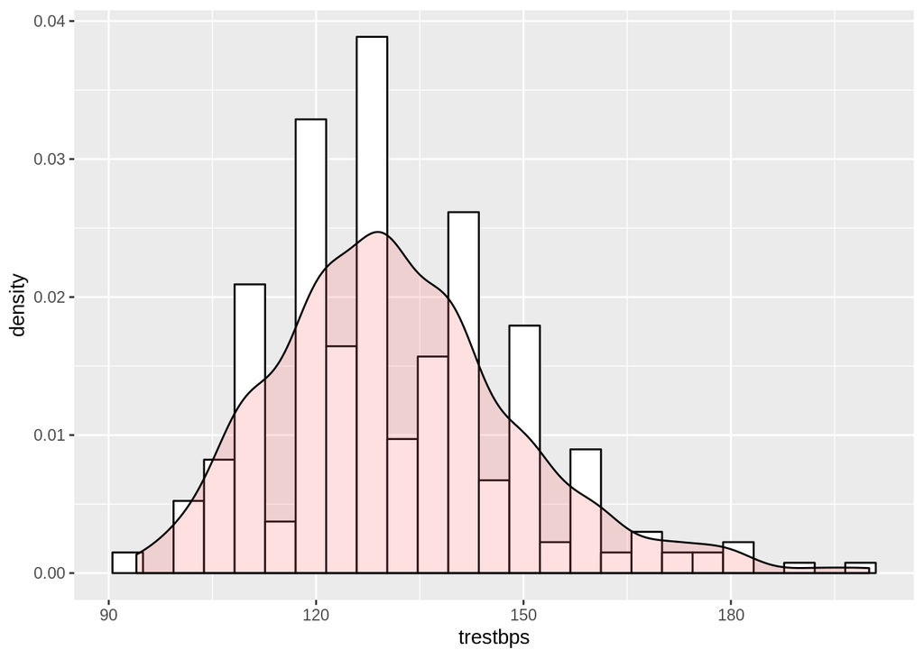

```r
ggplot(data, aes(x=trestbps)) +
    geom_histogram(aes(y=..density..),
                   bins=25,
                   colour="black", fill="white") +
    geom_density(alpha=.2, fill="#FF6666")
```

# 3 Wykresy dla zmiennych dyskretnych

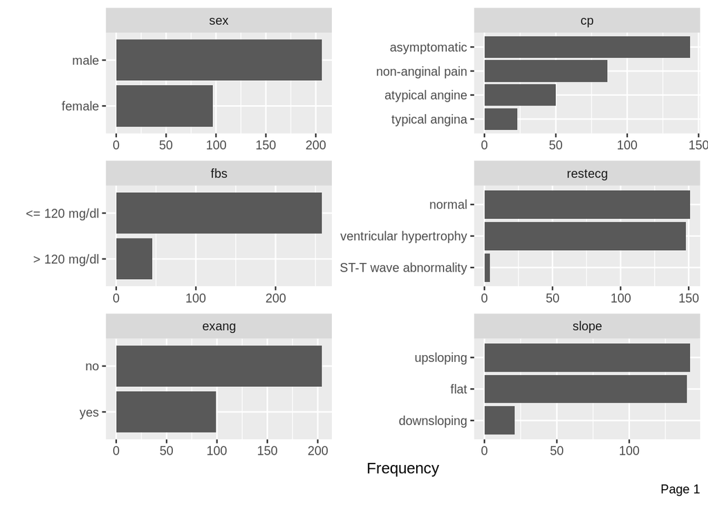

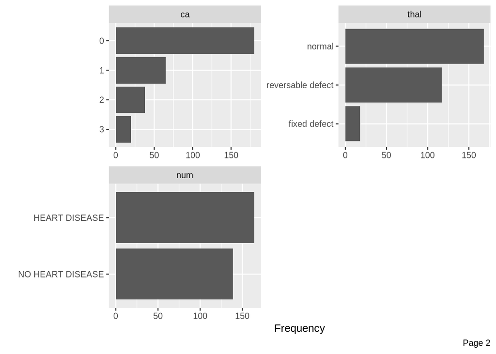

```r
plot_bar(data, ncol = 2)
```

# 4 Wykresy Q-Q

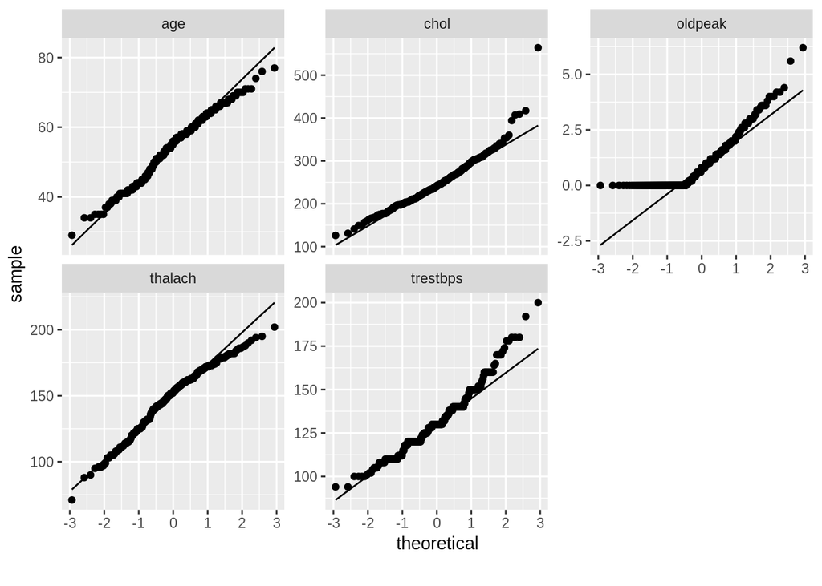

```r
plot_qq(data)
```

# 5 Wykresy korelacji zmiennych

Korelacja zmiennych dla niezmodyfikowanej ramki danych

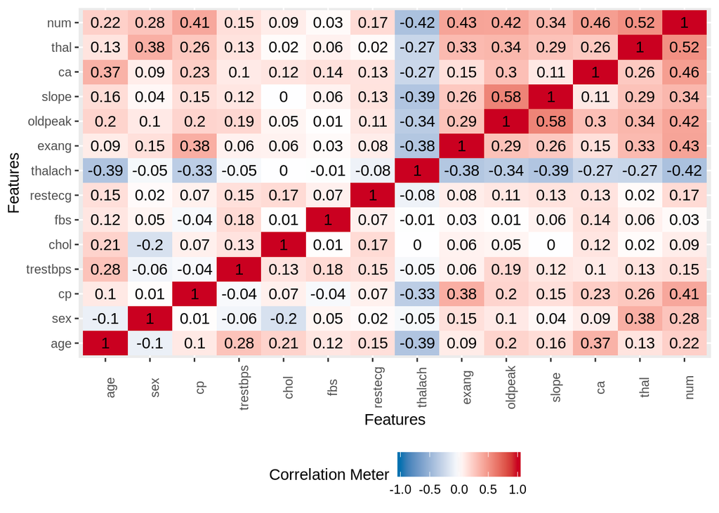

```r
plot_correlation(data1)
```

## 5.1 Korelacja zmiennych ciągłych

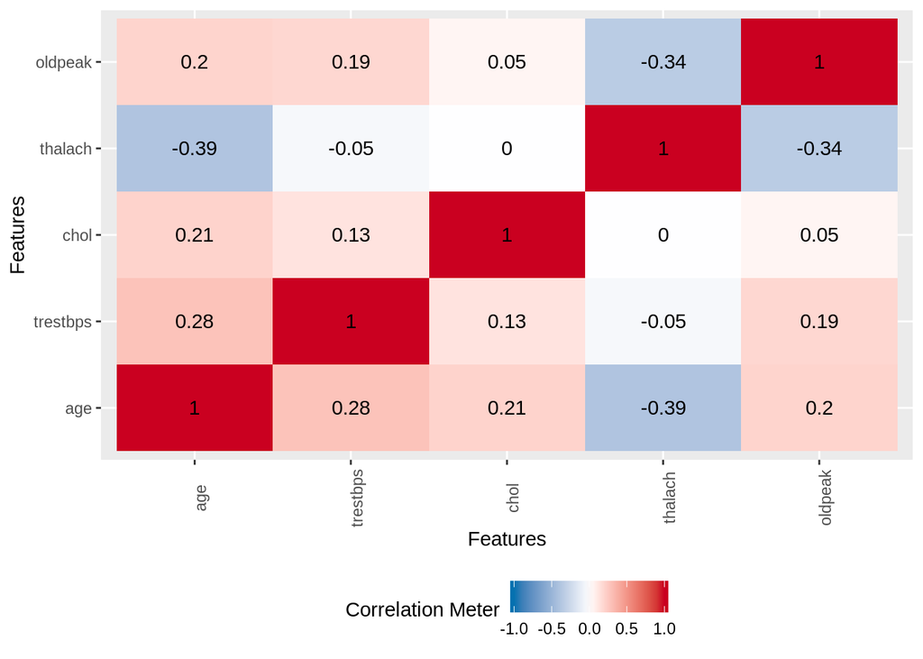

```r
plot_correlation(data, type = "continuous")
```

## 5.2 Korelacja zmiennych dyskretnych

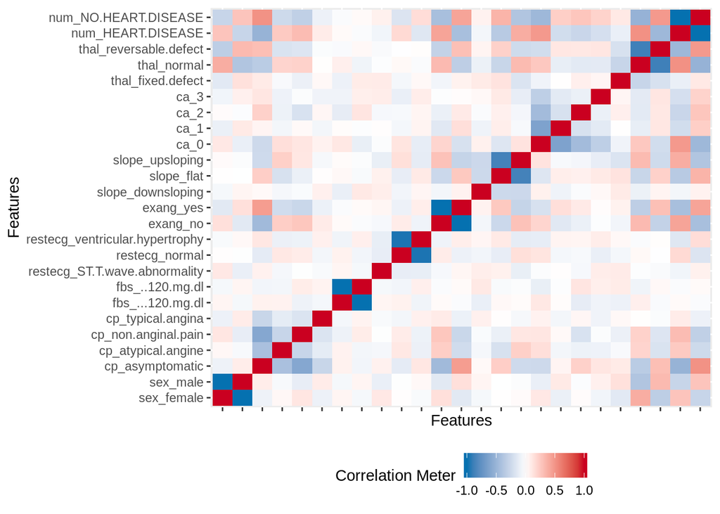

```r
plot_correlation(data, type = "discrete", cor_args = list("use" = "pairwise.complete.obs"), theme_config = list(legend.position = "bottom", axis.text.x = element_blank()))
```

# 6 Wykresy skrzynkowe

## 6.1 Względem płci

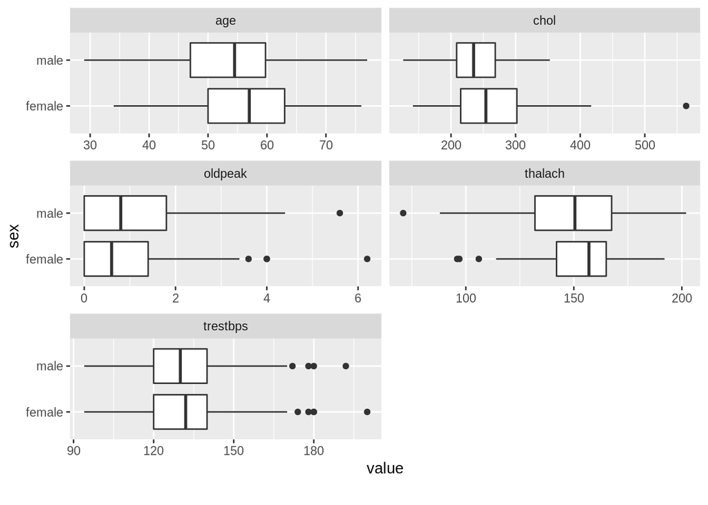

```r
plot_boxplot(data, by = "sex", ncol = 2)
```

## 6.2 Względem przewidywania choroby serca

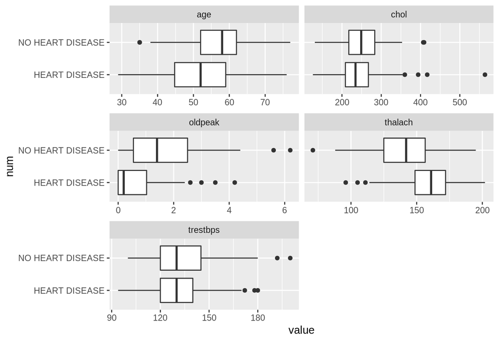

```r
plot_boxplot(data, by = "num", ncol = 2)
```

## 6.3 Względem wieku

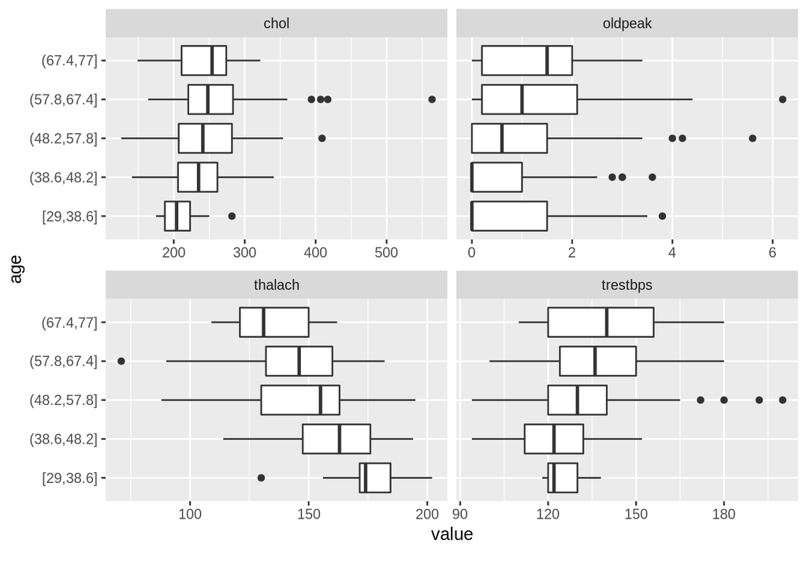

```r
plot_boxplot(data, by = "age", ncol = 2)
```

# 7 Wnioski i zależności

Pakiet Data_explorer pozwala na automatyczne wygenerowanie raportu i zautomatyzowanie analizy danych (w pewnym stopniu). Raport jest świetnym narzędziem do rozpoczęcia analizy zbioru danych. Pozwala uchwycić najważniejsze zależności i skierować wysiłki w odpowiednią stronę. Jednak posiada on kilka wad: nie jest w stanie poprawnie rozróżnić zmiennych dyskretnych od ciągłych i zauważyć oczywistych braków/błędów w danych. Jednak przy odpowiedniej modyfikacji zbioru da się wyciągnąć pewne zależności i ciekawostki ze zbioru.